# Homework 2

Logan Caraco

```r
library(ggplot2)
library(dplyr)
library(fivethirtyeight)

library(magrittr)

data("bechdel")
```

# Exercise 1

## Part a

```r
# Define a new variable which measures years_since_1900
bechdel %<>% mutate(years_since_1900 = year - 1900)

# NOTE: var-name %<>% func is syn sugar for var-name <- var-name %>% func
```

```r
bechdel %>%
  select(year, years_since_1900) %>%
  head(3)
```

```
## # A tibble: 3 x 2
##    year years_since_1900
##   <int>            <dbl>
## 1  2013              113
## 2  2012              112
## 3  2013              113
```

## Part b

```r
bechdel %<>%
  mutate(budget_mil = budget / 1e6) %>%
  mutate(intgross_mil = intgross / 1e6)
```

```r
bechdel %>%
  select(budget_mil, intgross_mil) %>%
  head(3)
```

```
## # A tibble: 3 x 2
##   budget_mil intgross_mil
##        <dbl>        <dbl>
## 1         13         42.2
## 2         45         40.9
## 3         20        159.
```

# Exercise 2

```r
# How many films are in the dataset?
nrow(bechdel)
```

```
## [1] 1794
```

```r
# When was the oldest film in the dataset made?
bechdel %>%
  summarize(min(year))
```

```
## # A tibble: 1 x 1
##   `min(year)`
##         <int>
## 1        1970
```

```r
# When was the most recent film in the dataset made?
bechdel %>%
  summarize(max(year))
```

```
## # A tibble: 1 x 1
##   `max(year)`
##         <int>
## 1        2013
```

```r
# What is the median film budget in 2013 dollars?
bechdel %>%
  summarize(median(budget_2013))
```

```
## # A tibble: 1 x 1
##   `median(budget_2013)`
##                   <dbl>
## 1              36995786
```

```r
# What films had budgets that exceeded 300 million in 2013 dollars?
# (Just show the films and budgets, not all variables)
bechdel %>%
  select(title, budget_2013) %>%
  filter(budget_2013 > 300000000)
```

[output not shown]

```r
# What films were made in 1971?
# (Just show the films and year, not all variables)
bechdel %>%
  select(title, year) %>%
  filter(year == 1971)
```

```
## # A tibble: 5 x 2
##   title                                year
##   <chr>                               <int>
## 1 Escape from the Planet of the Apes   1971
## 2 Shaft                                1971
## 3 Straw Dogs                           1971
## 4 The French Connection                1971
## 5 Willy Wonka & the Chocolate Factory  1971
```

```r
# What were the budget_mil and intgross_mil values for "Titanic"?
# (Just show the budget_mil and intgross_mil values)
bechdel %>%
  filter(title == "Titanic") %>%
  select(budget_mil, intgross_mil)
```

```
## # A tibble: 1 x 2
##   budget_mil intgross_mil
##        <dbl>        <dbl>
## 1        200        2186.
```

# Exercise 3

```r
bechdel %>%
  group_by(clean_test) %>%
  summarize(count = n())
```

```
## # A tibble: 5 x 2
##   clean_test count
## * <ord>      <int>
## 1 nowomen      141
## 2 notalk       514
## 3 men          194
## 4 dubious      142
## 5 ok           803
```

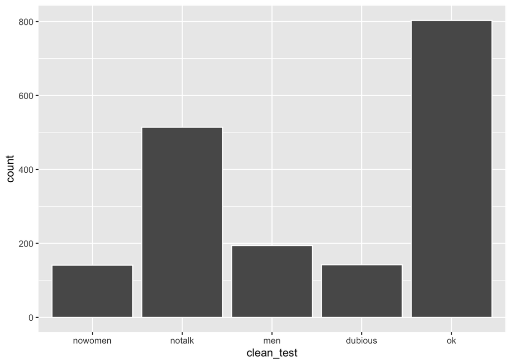

```r
ggplot(bechdel, aes(x = clean_test)) +
  geom_histogram(color = "white", stat="count")
```

# Exercise 4

The vast majority of movies make less than 200 million dollars, but there are movies that made in excess of $1B.

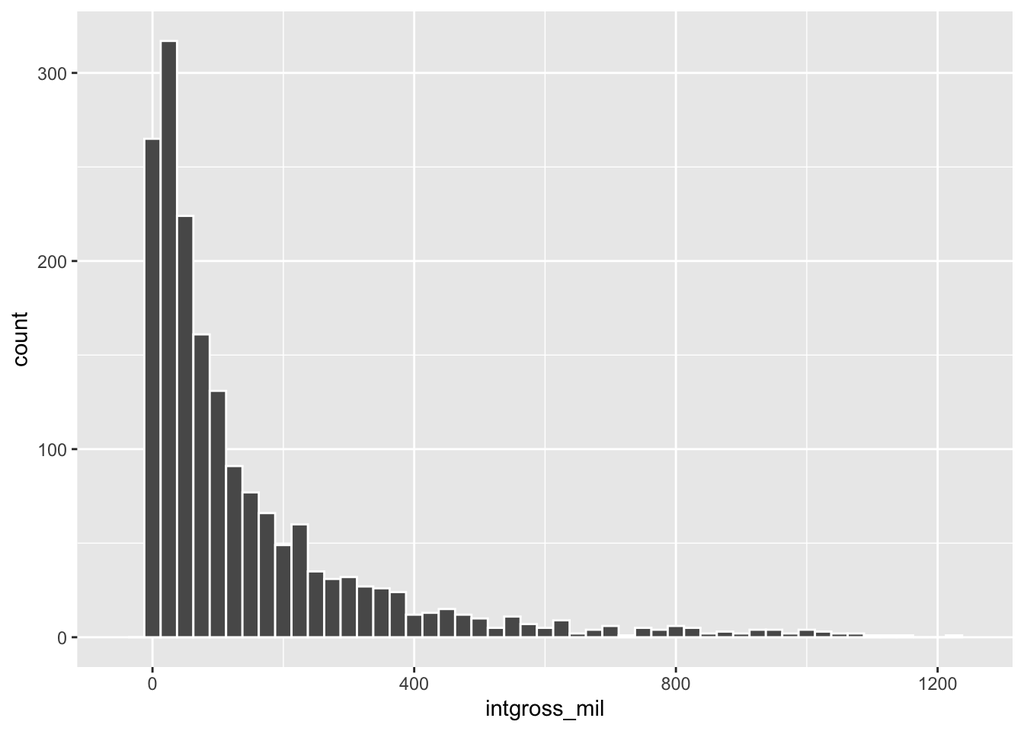

```r
ggplot(bechdel, aes(x = intgross_mil)) +
  geom_histogram(color = "white", binwidth = 25) +
  xlim(-50, 1250)
```

```r
bechdel %>%
  summarize(mean(intgross_mil, na.rm=TRUE), median(intgross_mil, na.rm=TRUE))
```

```
## # A tibble: 1 x 2
##   `mean(intgross_mil, na.rm = TRUE)` `median(intgross_mil, na.rm = TRUE)`
##                                <dbl>                                <dbl>
## 1                               150.                                 76.5
```

The median is much lower than the mean because there is a long and short right tail which contributes heavily to the median, and barely at all to the median.

```r
bechdel %>%
  summarize(sd(intgross_mil, na.rm=TRUE), sd(budget, na.rm=TRUE)/1000000)
```

```
## # A tibble: 1 x 2
##   `sd(intgross_mil, na.rm = TRUE)` `sd(budget, na.rm = TRUE)/1e+06`
##                              <dbl>                            <dbl>
## 1                             210.                             48.2
```

The budget is relatively tightly grouped, whereas the gross is highly variable. Therefore it is a risky venture to create a high budget movie, because the chance of payout can be slim.

# Exercise 5

$\texttt{intgross_mil}$ is the response variable to $\texttt{budget}$.

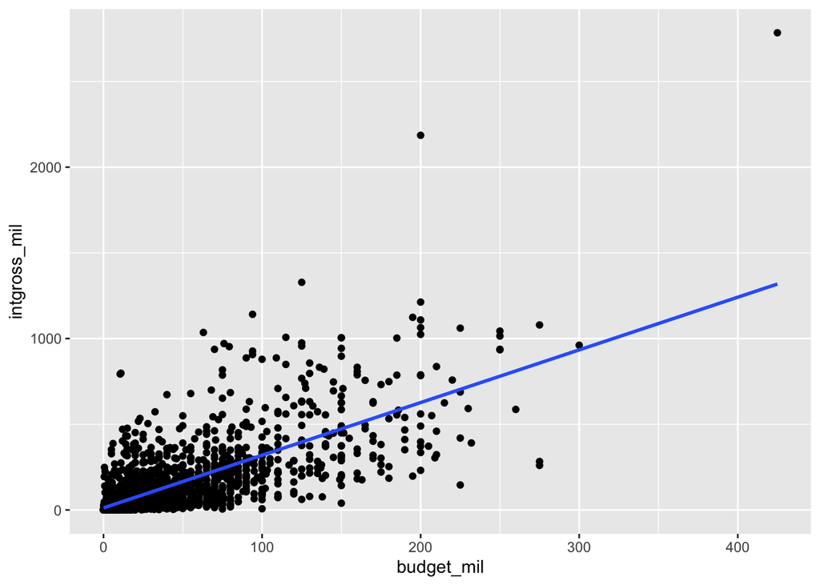

```r
bechdel %>%
  ggplot(aes(y = intgross_mil, x = budget_mil)) +
  geom_point() +                         # <<< plot
  geom_smooth(method = "lm", se = FALSE) # <<< trend
```

As seen in the plot above, there is an (unsuprisingly) positive relationship between budget and international gross, thought the underestimates of the model tend to be greater than the overestimates.

# Exercise 6

```r
summary(movie_model <- lm(intgross_mil ~ budget_mil, data = bechdel))$coefficients
```

```
##              Estimate Std. Error   t value      Pr(>|t|)
## (Intercept) 11.949578 4.83550221  2.471218  1.355834e-02
## budget_mil   3.073115 0.07326585 41.944714 5.220794e-268
```

The regression trendline:
$$\texttt{intgross_mil} = 11.95 + 3.07~ \texttt{budget_mil}$$
Roughly, every million dollars put into the budget of the movie increases the international gross by three million dollars (or return on a $1M investment is twofold).

The intercept is not totally intuitive as a movie with budget of $0 would unlikely have a $12M gross, it makes more sense to say that million-dollar budget movies tend to gross 15M.

# Exercise 7

$$\texttt{budget_mil}_{Titanic} = 200$$
$$\texttt{intgross_mil} = 11.95 + 3.07~ \texttt{budget_mil} = 625.95$$

```r
predict(movie_model, newdata = data.frame(budget_mil = 200))
```

```
##        1
## 626.5726
```

$$\texttt{intgross_mil}_{actual}=2185.672$$
$$\textbf r = actual - predicted = 2185.672 - 626.572 = 1559.1$$

The model *grossly* underestimated the gross.

# Exercise 8

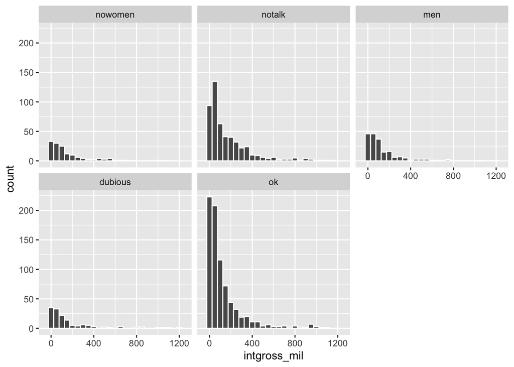

```r
ggplot(bechdel, aes(x = intgross_mil, color = clean_test)) +
  geom_histogram(color = "white", binwidth = 50) +
  facet_wrap(~ clean_test) +
  xlim(-50, 1250)
```

```r
bechdel %>%
  group_by(clean_test) %>%
  summarize(mean(intgross_mil, na.rm=TRUE), sd(intgross_mil, na.rm=TRUE))
```

```
## # A tibble: 5 x 3
##   clean_test `mean(intgross_mil, na.rm = TRUE)` `sd(intgross_mil, na.rm = TRUE)`
## * <ord>                                   <dbl>                            <dbl>
## 1 nowomen                                  147.                             178.
## 2 notalk                                   175.                             212.
## 3 men                                      146.                             250.
## 4 dubious                                  169.                             241.
## 5 ok                                       133.                             196.
```

# Exercise 9

```r
bechdel <- bechdel %>%
  mutate(clean_test = factor(as.character(clean_test)))
movie_model_2 <- lm(intgross_mil ~ clean_test, data = bechdel)
summary(movie_model_2)$coefficients
```

```
##                     Estimate Std. Error    t value     Pr(>|t|)
## (Intercept)       169.341537   17.66275  9.5874931 2.918621e-21
## clean_testmen     -23.116822   23.23555 -0.9948901 3.199251e-01
## clean_testnotalk    6.040527   19.94711  0.3028272 7.620570e-01
## clean_testnowomen -22.784665   25.06860 -0.9088927 3.635300e-01
## clean_testok      -36.669666   19.15975 -1.9138908 5.579450e-02
```

The baseline for $\texttt{clean_test}$ is $\texttt{dubious}$.

$\texttt{dubious}$ movies tend to gross 169 million. $\texttt{men}$ movies tend to make 23M less than $\texttt{dubious}$ ones.

The $\texttt{notalk}$ movies (in which women are present on screen but do not speak) have the highest average gross of 175M. The $\texttt{ok}$ movies (which pass the Bechdel test) have the lowest average gross of 132.7M.